# what's stopping people from receiving COVID vaccines?

#### *an introductory data science tutorial, presented by annie fang*

With COVID vaccinations rolling out in the US, new reports are broadcasting that vaccinations are plateauing. Naturally, we might think - what's stopping people from receiving COVID vaccines? Is it access? Is it information? Is it low vaccine confidence? And, which populations are most at risk, be it any of the above reasons?

# what are we trying to do here?

In the following tutorial, we're going to attempt to identify which communities might be most at risk if we consider vaccine hesitancy, a community's vulnerability to disaster, and potential supply-demand challenges.

In addition, we'll take a look at whether there are any correlations between vaccine hesitancy and other variables such as education-level and median household income.

# why should this matter to me?

Understanding which individuals might be choosing not to or are unable to receive COVID vaccines might lead us towards more targeted marketing, resource-delegation, volunteer efforts, and dissemination of information.

Furthermore, as we move past the highest-risk individuals, based on pre-existing health conditions and occupations, we need a new way to identify risk.

As COVID vaccines roll-out, there are a plethora of reasons as to why individuals might not be getting vaccinated. As such, I hope that this tutorial helps build a bit of empathy and awareness.

# data sources

In this tutorial, we'll use data collected from two different sources:

> 1) [vaccine hesitancy](https://catalog.data.gov/dataset/vaccine-hesitancy-for-covid-19-county-and-local-estimates)

> 2) [education/unemployment data](https://www.ers.usda.gov/data-products/county-level-data-sets/download-data/)

# combining and cleaning data

Now that we've found some appropriate data, we're going to take a stab at combining these separate data sources.

For that, the first thing we'll need to do is access our data - let's do this using the Python package *pandas*.

*pandas* will let us play around with our datasets, which are in the form of .xls and .csv files, and turn them into matrix-like objects called dataframes. The *pandas* package is full of functionality that allows us to perform tasks such as removing columns/rows, filtering for data that meets specific conditions, grouping data by feature, handling missing data, and much more. You can read more about *pandas* [here](https://pandas.pydata.org/docs/user_guide/index.html).

```python
import pandas as pd

# load in all 3 datasets into pandas dataframes
hesitancy = pd.read_csv("vaccine_hesitancy.csv")

# the sheet_name parameter lets us read in a single sheet, since .xls documents often contain multiple Excel sheets
education = pd.read_excel("education.xls", sheet_name="Education 1970 to 2019")
unemployment = pd.read_excel("unemployment.xls", sheet_name="Unemployment Med HH Income")
```

Since this data wasn't necessarily intended to be used in the form of a *pandas* dataframe, we'll likely need to do some tinkering to get things into a cleaner format.

That being said, let's take a look at one of our datasets:

```python
education.head(5)
```

|  | Educational attainment for adults age 25 and older for the U.S., States, and counties, 1970-2019 | Unnamed: 1 | Unnamed: 2 | Unnamed: 3 | Unnamed: 4 | Unnamed: 5 | Unnamed: 6 | Unnamed: 7 | Unnamed: 8 | Unnamed: 9 | ... | Unnamed: 37 | Unnamed: 38 | Unnamed: 39 | Unnamed: 40 | Unnamed: 41 | Unnamed: 42 | Unnamed: 43 | Unnamed: 44 | Unnamed: 45 | Unnamed: 46 |
| --- | --- | --- | --- | --- | --- | --- | --- | --- | --- | --- | --- | --- | --- | --- | --- | --- | --- | --- | --- | --- | --- |
| 0 | Sources: U.S. Census Bureau, 1970, 1980, 1990,... | NaN | NaN | NaN | NaN | NaN | NaN | NaN | NaN | NaN | ... | NaN | NaN | NaN | NaN | NaN | NaN | NaN | NaN | NaN | NaN |
| 1 | For definitions of rural classifications, see ... | NaN | NaN | NaN | NaN | NaN | NaN | NaN | NaN | NaN | ... | NaN | NaN | NaN | NaN | NaN | NaN | NaN | NaN | NaN | NaN |
| 2 | This table was prepared by USDA, Economic Rese... | NaN | NaN | NaN | NaN | NaN | NaN | NaN | NaN | NaN | ... | NaN | NaN | NaN | NaN | NaN | NaN | NaN | NaN | NaN | NaN |
| 3 | FIPS Code | State | Area name | 2003 Rural-urban Continuum Code | 2003 Urban Influence Code | 2013 Rural-urban Continuum Code | 2013 Urban Influence Code | Less than a high school diploma, 1970 | High school diploma only, 1970 | Some college (1-3 years), 1970 | ... | Percent of adults completing some college or a... | Percent of adults with a bachelor's degree or ... | Less than a high school diploma, 2015-19 | High school diploma only, 2015-19 | Some college or associate's degree, 2015-19 | Bachelor's degree or higher, 2015-19 | Percent of adults with less than a high school... | Percent of adults with a high school diploma o... | Percent of adults completing some college or a... | Percent of adults with a bachelor's degree or ... |
| 4 | 00000 | US | United States | NaN | NaN | NaN | NaN | 52373312 | 34158051 | 11650730 | ... | 27.4 | 24.4 | 26472261 | 59472748 | 63756905 | 70920162 | 11.9989 | 26.9568 | 28.8987 | 32.1455 |

5 rows × 47 columns

Oh no! Looks like there are some extraneous rows of text, so our column names are actually in the 3rd row of our dataframe. And, it seems that we have way too many columns worth of data. Since we'll be combining this dataset with our vaccine hesitancy dataset, which pertains to survey data collected in 2021, let's extract just the most recent data regarding education.

Let's go ahead and do some clean up by setting our dataframe's column names to the 3rd row of observations, and let's also get rid of all of those rows/columns that we won't need.

```python
# set dataframe's column titles to the row at index 3
education.columns = education.iloc[3]

# drop the first few rows of plaintext (non-data)
education = education.drop(education.index[0:4])

# drop columns index 3 to 42, leaving only 2015-2019 data
education.drop(education.iloc[:, 3:43], inplace = True, axis = 1)
education.head(5)
```

| 3 | FIPS Code | State | Area name | Percent of adults with less than a high school diploma, 2015-19 | Percent of adults with a high school diploma only, 2015-19 | Percent of adults completing some college or associate's degree, 2015-19 | Percent of adults with a bachelor's degree or higher, 2015-19 |
| --- | --- | --- | --- | --- | --- | --- | --- |
| 4 | 00000 | US | United States | 11.9989 | 26.9568 | 28.8987 | 32.1455 |
| 5 | 01000 | AL | Alabama | 13.8193 | 30.8003 | 29.9121 | 25.4683 |
| 6 | 01001 | AL | Autauga County | 11.4834 | 33.5885 | 28.3566 | 26.5716 |
| 7 | 01003 | AL | Baldwin County | 9.19384 | 27.6596 | 31.2841 | 31.8625 |
| 8 | 01005 | AL | Barbour County | 26.7869 | 35.6045 | 26.0298 | 11.5787 |

Great, now let's do the same with the remaining dataframes!

```python
# set dataframe's column titles to the row at index 3
unemployment.columns = unemployment.iloc[3]

# drop the first few rows of paintext (non-data)
unemployment = unemployment.drop(unemployment.index[0:4])

# drop columns index 3 to 84, leaving only 2019 data
unemployment.drop(unemployment.iloc[:, 3:85], inplace = True, axis = 1)
unemployment.head(5)
```

| 3 | fips_txt | Stabr | area_name | Unemployment_rate_2019 | Median_Household_Income_2019 | Med_HH_Income_Percent_of_State_Total_2019 |
| --- | --- | --- | --- | --- | --- | --- |
| 4 | 00000 | US | United States | 3.66941 | 65712 | NaN |
| 5 | 01000 | AL | Alabama | 3 | 51771 | 100 |
| 6 | 01001 | AL | Autauga County, AL | 2.7 | 58233 | 112.482 |
| 7 | 01003 | AL | Baldwin County, AL | 2.7 | 59871 | 115.646 |
| 8 | 01005 | AL | Barbour County, AL | 3.8 | 35972 | 69.4829 |

```python
# select vaccine hesistance, social vulnerability, and county/state boundary data
hesitancy = hesitancy[['FIPS Code', 'County Name', 'State', 'State Code', 'Estimated hesitant',
       'Estimated strongly hesitant', 'Social Vulnerability Index (SVI)',
       'SVI Category', 'County Boundary', 'State Boundary']]
hesitancy.head(5)
```

|  | FIPS Code | County Name | State | State Code | Estimated hesitant | Estimated strongly hesitant | Social Vulnerability Index (SVI) | SVI Category | County Boundary | State Boundary |
| --- | --- | --- | --- | --- | --- | --- | --- | --- | --- | --- |
| 0 | 1131 | Wilcox County, Alabama | ALABAMA | AL | 0.23 | 0.11 | 0.93 | Very High Concern | MULTIPOLYGON (((-87.52534299999999 32.132773, ... | MULTIPOLYGON (((-88.139988 34.581703, -88.1352... |
| 1 | 1129 | Washington County, Alabama | ALABAMA | AL | 0.23 | 0.11 | 0.73 | High Concern | MULTIPOLYGON (((-88.45317899999999 31.505388, ... | MULTIPOLYGON (((-88.139988 34.581703, -88.1352... |
| 2 | 1133 | Winston County, Alabama | ALABAMA | AL | 0.22 | 0.11 | 0.70 | High Concern | MULTIPOLYGON (((-87.63656399999999 34.120908, ... | MULTIPOLYGON (((-88.139988 34.581703, -88.1352... |
| 3 | 1127 | Walker County, Alabama | ALABAMA | AL | 0.23 | 0.11 | 0.75 | High Concern | MULTIPOLYGON (((-87.56108499999999 33.868713, ... | MULTIPOLYGON (((-88.139988 34.581703, -88.1352... |
| 4 | 2013 | Aleutians East Borough, Alaska | ALASKA | AK | 0.26 | 0.12 | 0.58 | Moderate Concern | MULTIPOLYGON (((-165.036163 54.576598, -165.01... | MULTIPOLYGON (((-165.254162 60.917108, -165.30... |

We're close to being able to combine our three data sources, but we need to do one last thing. *pandas* generates a datatype for each of the varibles in our dataset, but they might not be the most appropriate type for that particular data.

So, we're going to use .dtypes to check what each variable's type is, apply .convert_dtypes(), and make sure the data types were converted to more suitable data types.

```python
education = education.convert_dtypes()
unemployment = unemployment.convert_dtypes()
hesitancy = hesitancy.convert_dtypes()
```

```python
education.head(10)
```

|  | FIPS Code | State | Area name | Percent of adults with less than a high school diploma, 2015-19 | Percent of adults with a high school diploma only, 2015-19 | Percent of adults completing some college or associate's degree, 2015-19 | Percent of adults with a bachelor's degree or higher, 2015-19 |
| --- | --- | --- | --- | --- | --- | --- | --- |
| 4 | 00000 | US | United States | 11.998918 | 26.956844 | 28.898697 | 32.145542 |
| 5 | 01000 | AL | Alabama | 13.819302 | 30.800268 | 29.912098 | 25.468332 |
| 6 | 01001 | AL | Autauga County | 11.483395 | 33.588459 | 28.356571 | 26.571573 |
| 7 | 01003 | AL | Baldwin County | 9.193843 | 27.659616 | 31.284081 | 31.862459 |
| 8 | 01005 | AL | Barbour County | 26.786907 | 35.604542 | 26.029837 | 11.578713 |
| 9 | 01007 | AL | Bibb County | 20.942602 | 44.878773 | 23.800098 | 10.378526 |
| 10 | 01009 | AL | Blount County | 19.509438 | 33.422131 | 33.975021 | 13.093413 |
| 11 | 01011 | AL | Bullock County | 25.320377 | 40.276016 | 22.348965 | 12.054640 |
| 12 | 01013 | AL | Butler County | 14.950431 | 45.184166 | 23.728201 | 16.137203 |
| 13 | 01015 | AL | Calhoun County | 15.567326 | 32.790615 | 33.160995 | 18.481064 |

```python
unemployment.head(10)
```

|  | fips_txt | Stabr | area_name | Unemployment_rate_2019 | Median_Household_Income_2019 | Med_HH_Income_Percent_of_State_Total_2019 |
| --- | --- | --- | --- | --- | --- | --- |
| 4 | 00000 | US | United States | 3.669409 | 65712 | NaN |
| 5 | 01000 | AL | Alabama | 3.000000 | 51771 | 100.000000 |
| 6 | 01001 | AL | Autauga County, AL | 2.700000 | 58233 | 112.481888 |
| 7 | 01003 | AL | Baldwin County, AL | 2.700000 | 59871 | 115.645828 |
| 8 | 01005 | AL | Barbour County, AL | 3.800000 | 35972 | 69.482918 |
| 9 | 01007 | AL | Bibb County, AL | 3.100000 | 47918 | 92.557610 |
| 10 | 01009 | AL | Blount County, AL | 2.700000 | 52902 | 102.184624 |
| 11 | 01011 | AL | Bullock County, AL | 3.600000 | 31906 | 61.629097 |
| 12 | 01013 | AL | Butler County, AL | 3.600000 | 39944 | 77.155167 |
| 13 | 01015 | AL | Calhoun County, AL | 3.500000 | 47747 | 92.227310 |

Now that our data is tagged with a more appropriate datatype, we can move on to merging our dataframes

```python
# merge the vaccine hesitancy and education datasets together using the FIPS codes, which are unique to each county in the US
combined_df = pd.merge(hesitancy, education, left_on='FIPS Code', right_on='FIPS Code')

# merge the prior combined dataset with the unemployment dataset, once again using the unique FIPS identifiers
combined_df = pd.merge(combined_df, unemployment, left_on='FIPS Code', right_on='fips_txt')

# remove any redundant columns
combined_df = combined_df.drop(columns=[ 'State_y', 'Area name', 'fips_txt', 'Stabr', 'area_name'])
combined_df.head(5)
```

|  | FIPS Code | County Name | State_x | State Code | Estimated hesitant | Estimated strongly hesitant | Social Vulnerability Index (SVI) | SVI Category | County Boundary | State Boundary | Percent of adults with less than a high school diploma, 2015-19 | Percent of adults with a high school diploma only, 2015-19 | Percent of adults completing some college or associate's degree, 2015-19 | Percent of adults with a bachelor's degree or higher, 2015-19 | Unemployment_rate_2019 | Median_Household_Income_2019 | Med_HH_Income_Percent_of_State_Total_2019 |
| --- | --- | --- | --- | --- | --- | --- | --- | --- | --- | --- | --- | --- | --- | --- | --- | --- | --- |
| 0 | 13105 | Elbert County, Georgia | GEORGIA | GA | 0.22 | 0.10 | 0.83 | Very High Concern | MULTIPOLYGON (((-82.934512 34.234904, -82.9155... | MULTIPOLYGON (((-85.38658099999999 33.901719, ... | 21.573318 | 40.903313 | 25.880505 | 11.642862 | 4.0 | 40962 | 66.121063 |
| 1 | 13115 | Floyd County, Georgia | GEORGIA | GA | 0.25 | 0.11 | 0.89 | Very High Concern | MULTIPOLYGON (((-85.24134099999999 34.415518, ... | MULTIPOLYGON (((-85.38658099999999 33.901719, ... | 17.562021 | 34.334114 | 27.218588 | 20.885275 | 3.8 | 50520 | 81.549637 |
| 2 | 13109 | Evans County, Georgia | GEORGIA | GA | 0.27 | 0.12 | 0.98 | Very High Concern | MULTIPOLYGON (((-82.003682 32.18365, -82.01928... | MULTIPOLYGON (((-85.38658099999999 33.901719, ... | 23.810184 | 38.851116 | 21.576246 | 15.762453 | 3.4 | 41425 | 66.868439 |
| 3 | 13111 | Fannin County, Georgia | GEORGIA | GA | 0.25 | 0.11 | 0.30 | Low Concern | MULTIPOLYGON (((-84.38288899999999 34.988001, ... | MULTIPOLYGON (((-85.38658099999999 33.901719, ... | 13.406223 | 33.495121 | 31.323763 | 21.774895 | 3.3 | 47980 | 77.449554 |
| 4 | 13107 | Emanuel County, Georgia | GEORGIA | GA | 0.26 | 0.12 | 0.98 | Very High Concern | MULTIPOLYGON (((-82.45218899999999 32.729699, ... | MULTIPOLYGON (((-85.38658099999999 33.901719, ... | 21.409851 | 40.830589 | 24.736240 | 13.023318 | 5.3 | 38529 | 62.193703 |

# exploratory data analysis

Yay! We've finally gotten all of our data into a more workable format - it's time to (figuratively) bash some rocks against each other and see what shows up.

To do so, we're going to visualize some of our data and see if any promising trends appear. *seaborn* and *matplotlib* are two packages that will help us visualize our data. You can explore these packages [here](https://seaborn.pydata.org/api.html) and [here](https://matplotlib.org/stable/tutorials/index.html), respectively.

```python
import seaborn as sns
import matplotlib.pyplot as plt
```

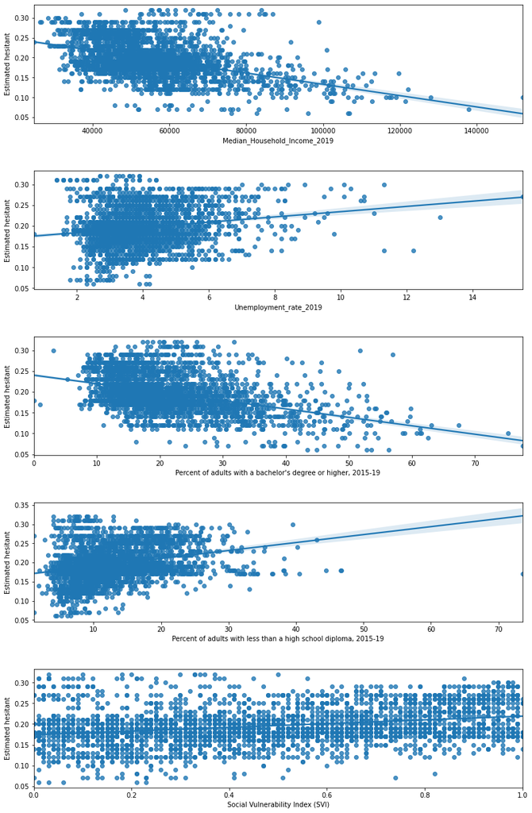

```python
fig, (ax1, ax2, ax3, ax4, ax5) = plt.subplots(5)

fig.set_size_inches(12, 18)
fig.tight_layout(pad=5.0)

combined_df["Median_Household_Income_2019"] = combined_df["Median_Household_Income_2019"].astype(float)
sns.regplot(ax=ax1, data=combined_df, x="Median_Household_Income_2019", y="Estimated hesitant")

sns.regplot(ax=ax2, data=combined_df, x="Unemployment_rate_2019", y="Estimated hesitant")

sns.regplot(ax=ax3, data=combined_df, x="Percent of adults with a bachelor's degree or higher, 2015-19", y="Estimated hesitant")

sns.regplot(ax=ax4, data=combined_df, x="Percent of adults with less than a high school diploma, 2015-19", y="Estimated hesitant")

sns.regplot(ax=ax5, data=combined_df, x="Social Vulnerability Index (SVI)", y="Estimated hesitant")
plt.show()
```

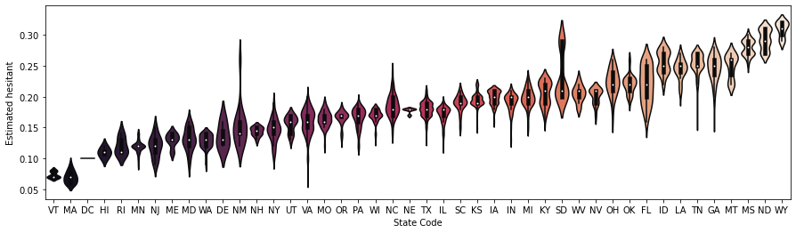

```python
plt.figure(figsize=(15, 4))
my_order = combined_df.groupby(by=["State Code"])["Estimated hesitant"].median().sort_values().index.values

sns.violinplot(x = "State Code", y = "Estimated hesitant", data = combined_df, palette = "rocket", scale = "width", order = my_order)
plt.show()
```

As example, we've plotted a couple of variables against hesitancy to see what happens. Here, we slapped on a linear regression line to better visualize if there might be some sort of linear trend in any of these relationships (however, this does not mean a linear regression model is appropriate for predicting vaccine hesitancy).

And, just for fun, we visualized the distribution of vaccine hesitancy by state, which tells us that some states have huge variations in vaccine hesitancy, such as New Mexico (NM) and Virginia (VA). Plus, some states like South Dakota (SD) and Idaho (ID) have what appears to be binomial distributions.

Going back to the scatterplots, as you might be able to see, some of these variables don't seem to indicate a strong linear relationship with vaccine hesitancy, specifically SVI, unemployment rate, and percent of adults with less than a high school diploma. On the other hand, median household income and the percentage of adults look promising. However, since these two variables are likely to be strongly correlated to each other (higher paying jobs typically correlate with higher degrees of education), a multi-regression doesn't seem appropriate. If you're curious about multi-regression models and its assumptions, you can check out [this](https://statistics.laerd.com/spss-tutorials/multiple-regression-using-spss-statistics.php#:~:text=Multiple%20regression%20is%20an%20extension,%2C%20target%20or%20criterion%20variable) resource.

So instead, let's just take a look at how well a linear regression model fits using median household income to predict vaccine hesitancy.

# machine learning

But FIRST, is it meaningful to use a linear regression model with these variables?

In order to generate **meaningful** results using a linear regression model, we have to satisfy 4 assumptions (more [here](https://www.statology.org/linear-regression-assumptions/)):

1. There exists a linear relationship
2. The residuals are independent (ie. residuals don't correlate with time)
3. The residuals are homoscedastic (aka. we have constant variance of our model's residuals for all values of median household income)
4. The residuals are normally distributed

Now, going through each assumption: we suspect that (1) holds true based on the previous visualizations we generated earlier. (2) doesn't really have to do with us since we're not dealing with time-series data.

So, let's investigate (3) and (4).

### generating a linear regression model

The *statsmodels* package (as you might have gathered from the name) provides tools for statistical analysis, including estimating various statistical models, of which linear regression is one. If you're interested in what else *statsmodels* has to offer, check out the official documentation [here](https://www.statsmodels.org/stable/index.html).

```python
import statsmodels.api as sm

# use statsmodel to fit the data to a linear regression model
combined_df['median_household_income_tenthousands'] = combined_df['Median_Household_Income_2019'] / 10000
X2 = sm.add_constant(combined_df['median_household_income_tenthousands'])
est = sm.OLS(combined_df['Estimated hesitant'], X2)
model = est.fit()

print(f'vaccine hesitancy = {model.params.median_household_income_tenthousands:.4f} * median household income + {model.params.const:.4f}')
```

```
vaccine hesitancy = -0.0142 * median household income + 0.2749
```

As you can see, our model presents that for every 10k increase in median household income, a county is predicted to have roughly ~1.4% less vaccine hesitancy in that same county. This might not seem like a lot, but 1% of a county can mean huge numbers in context. For example, Prince Georges County has nearly 1 million people - so 1% is ten thousand people!

However, keep in mind that we haven't established how strong the predictive power of this model is, and we have yet to fulfill our 4 assumptions.

```python
print("p-values:")
print(model.pvalues)

print("r-squared:")
print(model.rsquared)
```

```
p-values:
const                                    0.000000e+00
median_household_income_tenthousands    1.293974e-127
dtype: float64
r-squared:
0.18503892645879838
```

So, what do these numbers mean? Well, the significance/p-values of our models' variables are very close to 0, we would theoretically reject the supposed null hypothesis that no relationship exists between median household income and vaccine hesitancy.

However, this doesn't mean that the model we have is a good one (and we STILL haven't proven that this data is worthy of a mighty linear regression model). Low and behold, our r^2 value is quite low - this means only ~18.5% of vaccine hesitancy can be explained by median household income.

### residuals and assumptions 3 + 4

Now, to finally figure out whether all the work we've done was all for naught or not (pun-intended).

We'll start by calculating the residuals:

```python
# calculate the residuals
combined_df['expected_vaccinehesitancy'] = model.params.median_household_income_tenthousands*combined_df['median_household_income_tenthousands'] + model.params.const
combined_df['residual'] = combined_df['Estimated hesitant'] - combined_df['expected_vaccinehesitancy']
```

And then checking for constant variance (3),

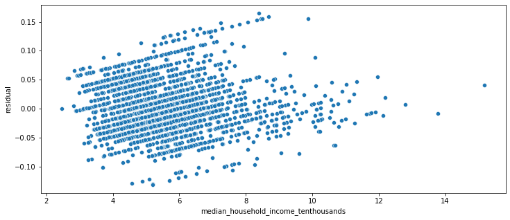

```python
plt.figure(figsize=(12,5))
sns.scatterplot(x = "median_household_income_tenthousands", y = "residual", data = combined_df)
plt.show()
```

And while we're at it, checking for normality (4)

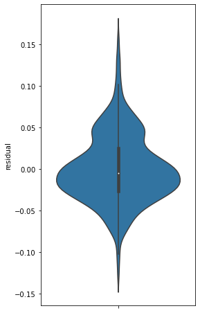

```python
plt.figure(figsize=(4, 8))
sns.violinplot(y = "residual", data = combined_df)
plt.show()
```

At this point, we see that we don't have a normal distribution of residuals, neither do we seem to have constant variance. So, it seems the assumptions for a linear regression model were NOT met.

However, not everything is for naught - you might notice that there almost a binomial distribution of residuals, which might indicate other variables at play that might be confounding the use of median household income as a predictor.

In fact, if we think about it more closely, what does median household income even represent? What happens to the meaning of median household income if an individual is living in New York City vs rural Georgia? Then, should we be normalizing our data respective of cost of living?

Let's see what happens if we take a look at this variable with respect to hesitancy.

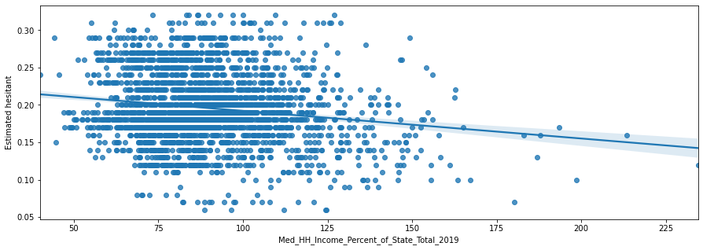

```python
plt.figure(figsize=(15, 5))
sns.regplot(data=combined_df, x="Med_HH_Income_Percent_of_State_Total_2019", y="Estimated hesitant")
plt.show()
```

Now, we don't see much of a linear relationship at all, so it's time to go back to the drawing board.

# conclusion

While we didn't identify a new variable to associate with higher vaccine hesistancy, we can observe which states seem to have the highest median vaccine hesitancies.

Through this tutorial, we hope that the difficulty of creating **meaningful** data analysis is apparent, and that problems involving human psychology, such as whether or not someone plans to get vaccinated, is multi-faceted and complex.

In fact, here's the twist of the entire vaccine hesitancy dataset (and a wake-up call to the potential dangers of the connotation of "vaccine hesitancy" and media reporting): the HPS survey also asked individuals why they are not planning on receiving a COVID vaccine or haven't received a COVID vaccine yet, which can be accessed on the HPS Census Data site. For any week's worth of data, Table 6 under Health Tables provides this data (however, in a very non-pandas digestible form). Just from this data alone, we can see that there are plethora of reasons contributing to the single number representing vaccine hesitancy.

# more resources

Like most problems involving humans, it's complicated.

If you want to learn more about what might be influencing COVID vaccine roll-out, you can checkout the following resources:

- [Surgo Ventures' U.S. COVID-19 Vaccine Coverage Index](https://vaccine.precisionforcovid.org/)

  > Surgo Ventures has quantified a multitude of factors that might increase the difficulty of attaining full community vaccination coverage, including historic undervaccination, sociodemographic barriers, healthcare infrastructure constraints, healthcare accessibility barriers, and irregular care-seeking behavior.
- [HPS Census Data](https://www.census.gov/programs-surveys/household-pulse-survey/data.html)

  > The Household Pulse Survey (HPS) has been and is currently collecting data regarding the impacts of COVID on people's live as part of the U.S. Census Bureau. [Here](https://www.census.gov/data/tables/2021/demo/hhp/hhp26.html), you can see the exact week's of raw data that was used by the CDC and U.S. Department of Health & Human Services to compute the vaccine hesitancy data that was used in this tutorial.

Some relevant articles:

- https://www.nytimes.com/interactive/2021/05/04/us/vaccine-rollout-slowing.html
- https://www.npr.org/2021/03/08/974705995/as-vaccinations-continue-covid-19-cases-plateau-is-progress-stalled
- https://www.statnews.com/2021/04/27/vaccinations-are-plateauing-dont-blame-it-on-resistance/
- https://www.nytimes.com/2021/03/05/opinion/us-covid-black-people.html

FYI, this is not a comprehensive list AT ALL, so do your own research and take everything with a grain of salt, including this tutorial :)

And if you're wondering how you can get a COVID vaccine, here's where you can start:

- https://www.cdc.gov/coronavirus/2019-ncov/vaccines/How-Do-I-Get-a-COVID-19-Vaccine.html

If you're concerned about the side effects of receiving a COVID vaccine, here's another starting point:

- https://www.cdc.gov/coronavirus/2019-ncov/vaccines/expect/after.html

And, if you didn't know already, getting a COVID vaccine in the U.S. should come at no cost, even if you don't have health insurance.